# Temps de passage

## Aspect graphique

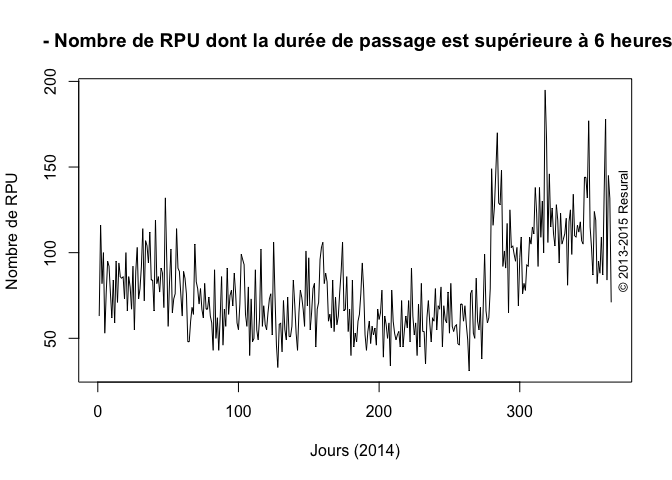

[figure not shown]

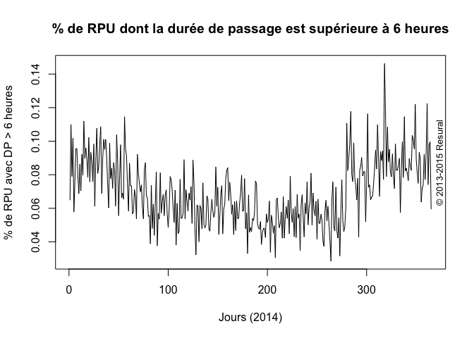

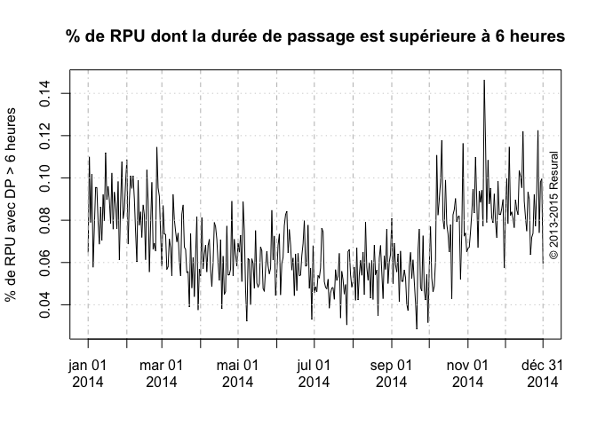

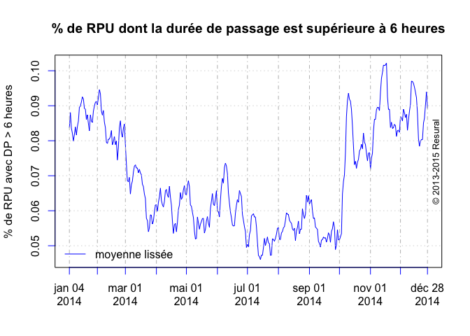

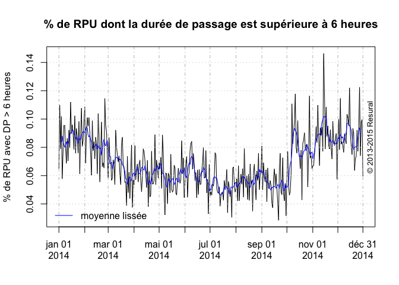

# Passages des plus de 75 ans

Patients agés de 75 ans ou plus.

```r
pop75 <- p14[p14$AGE > 74,]

summary(pop75$DPAS)
```

```
##    Min. 1st Qu.  Median    Mean 3rd Qu.    Max.    NA's
##     1.0    79.0   187.0   218.5   310.0  2880.0       4
```

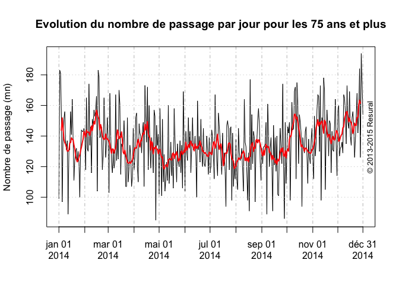

```r
pop75.jour <- tapply(as.Date(pop75$ENTREE), as.Date(pop75$ENTREE), length)
pop75.jour <- aligne.sur.calendrier(min(as.Date(pop75$ENTREE),na.rm=TRUE), max(as.Date(pop75$ENTREE),na.rm=TRUE), pop75.jour)

# plot(xts(pop75.jour, order.by = as.Date(rownames(pop75.jour))), minor.ticks = FALSE, ylab = "Nombre de passage (mn)", main = "Evolution du nombre de passage par jour pour les 75 ans et plus")

plot(xts(pop75.jour$rpu, order.by = as.Date(pop75.jour$calendrier)), minor.ticks = FALSE, ylab = "Nombre de passage (mn)", main = "Evolution du nombre de passage par jour pour les 75 ans et plus")

lines(rollmean(xts(pop75.jour$rpu, order.by = as.Date(pop75.jour$calendrier)), k = 7), col = "red", lwd = 2)
copyright()
```

Proportion des 75 ans par rapport à tous les RPU ————————————————–

```r
pop.tot <- tapply(as.Date(p14$ENTREE), as.Date(p14$ENTREE), length)
pop.tot <- aligne.sur.calendrier(min(as.Date(pop75$ENTREE),na.rm=TRUE), max(as.Date(pop75$ENTREE),na.rm=TRUE), pop.tot)
r <- pop75.jour$rpu * 100 / pop.tot$rpu
summary(r)
```

```
##    Min. 1st Qu.  Median    Mean 3rd Qu.    Max.
##   7.089  12.000  13.460  13.400  14.780  20.790
```

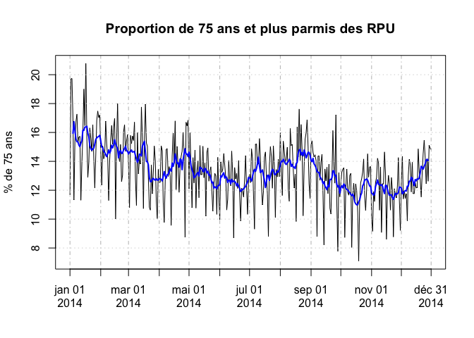

```r
plot(xts(r, order.by = as.Date(rownames(r))), minor.ticks = FALSE, ylab = "% de 75 ans", main = "Proportion de 75 ans et plus parmis des RPU")
lines(rollmean(xts(r, order.by = as.Date(rownames(r))), k = 7), col = "blue", lwd = 2)
```

# Taux hospitalisation

## Pour les plus de 75 ans

```r
source(paste0(path, "new_functions.R")) # f0nctopn mode.sotie()
ms <- mode.sortie(pop75) # plantage car les tableaux sont de taille inégale => rajouter aligne.sur.calendrier
head(ms)
```

```
##                  date passages.jour.rpu hospit.jour mutations.jour.rpu
## 2014-01-01 2014-01-01                99          57                 52
## 2014-01-02 2014-01-02               183         111                103
## 2014-01-03 2014-01-03               181         110                103
## 2014-01-04 2014-01-04               153          86                 83
## 2014-01-05 2014-01-05                97          54                 50
## 2014-01-06 2014-01-06               142          85                 83
##            transfert.jour.rpu taux.hosp
## 2014-01-01                  5     57.58
## 2014-01-02                  8     60.66
## 2014-01-03                  7     60.77
## 2014-01-04                  3     56.21
## 2014-01-05                  4     55.67
## 2014-01-06                  2     59.86
```

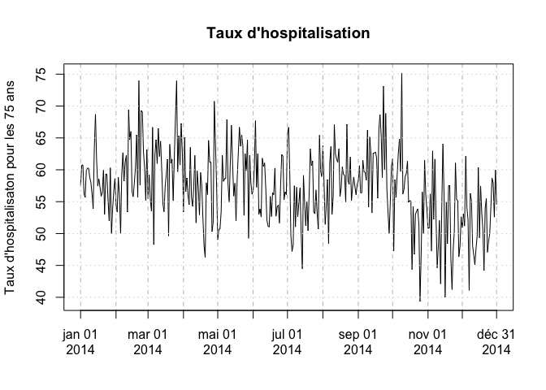

```r
hosp.xts <- xts(ms, order.by = as.Date(ms$date))
plot(hosp.xts$taux.hosp, minor.ticks = FALSE, ylab = "Taux d'hospitalisaton pour les 75 ans", main = "Taux d'hospitalisation")
```

# Question complémentaire (Schiber)

```r
# on ajoute une colonne pour les territoires
d14 <- add.territoire(d14)

# RPU > 74 ans
d14.pop75 <- d14[d14$AGE > 74,]

# nb de RPU > 74 ans par finess
rpu.finess.75ans <- tapply(as.Date(d14.pop75$ENTREE), d14.pop75$FINESS, length)
#  nb de RPU > 74 ans par territoire
rpu.territoire.75 <- tapply(as.Date(d14.pop75$ENTREE), d14.pop75$TERRITOIRE, length)
# nb de RPU par territoires
rpu.territoire <- tapply(as.Date(d14$ENTREE), d14$TERRITOIRE, length)
# nb de RPU par Finess
rpu.finess <- tapply(as.Date(d14$ENTREE), d14$FINESS, length)
# % de Rpu > 74 ans par finess
round(rpu.finess.75ans * 100/ rpu.finess, 2)
```

```
##   3Fr   Alk   Ane   Col   Dia   Dts   Geb   Hag   Hus   Mul   Odi   Ros
## 11.09 14.80  9.37 12.66 14.07  3.91 10.66 17.26 19.97 12.58  5.17  5.02
##   Sav   Sel   Wis
## 13.71 13.48 17.26
```

```r
# % de Rpu > 74 ans par territoire
round(rpu.territoire.75 * 100/ rpu.territoire, 2)
```

```
##    T1    T2    T3    T4
## 15.98 14.76 12.58 12.53
```

## Durée de passage en fonction de l’heure d’arrivée

L’heure d’arrivée a t’elle une influence sur la durée de passage ? Les sommes cumulées des durée de passage sont elles un indicateur, notamment les périodes de tension ?

On forme un dataframe avec:

- date
- heure d’entrée
- durée de passage
- motif
- DP
- Age

Rappel: si on commence ici il faut: library(lubridate) source(“Analyse/Temps_passage/passage.R”) load(“~/Documents/Resural/Stat Resural/RPU_2014/rpu2014d0112_c2.Rda”) # d14 (2014) load(“~/Documents/Resural/Stat Resural/RPU_2014/rpu2015d0112_provisoire.Rda”) # d15 (2015)

# pour 2014

# pour 2015

```
##        0        1        2        3        4        5        6        7
## 200.5799 187.1566 193.2850 201.1650 209.6375 208.7492 202.1397 176.0302
##        8        9       10       11       12       13       14       15
## 148.7852 152.9192 159.5309 165.7557 167.6780 162.7129 151.1152 149.5504
##       16       17       18       19       20       21       22       23
## 146.0409 144.6830 144.5115 139.4657 135.1092 140.2599 123.3579 124.7641
```

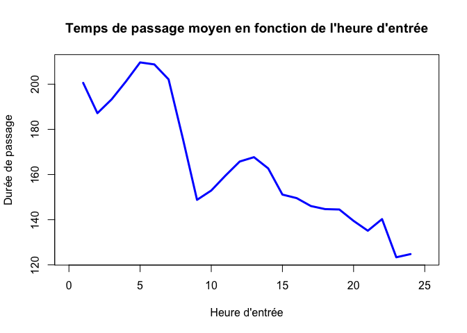

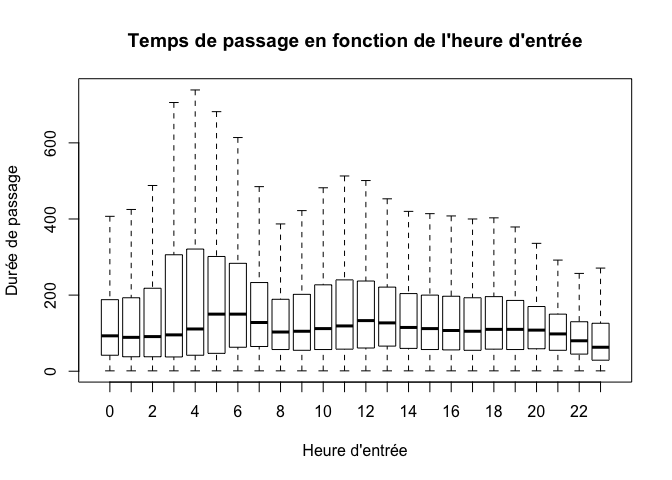

## Etude du cumul des temps de passage

On étudie la somme cumulée des durées de passage par heure d’entrée.

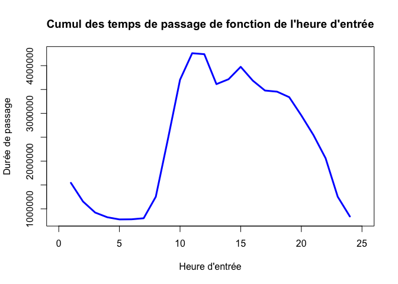

Le temps cumulé le plus long s’observe à 10 heures du matin. On isole le groupe 10 heures du matin pour voir comment il évolue au cours de l’année.

```
## [1] 365
```

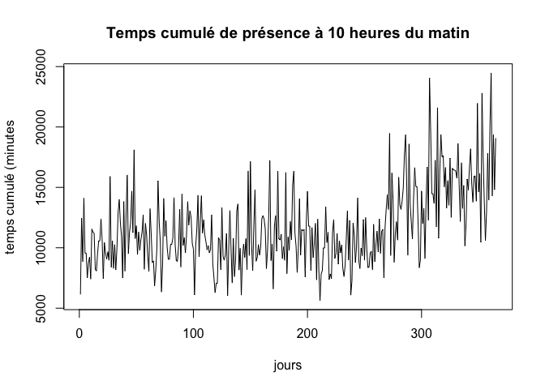

## CUSUM des sommes

Remarque: ne pas confondre CUSUM et cumsum = somme cumulative des éléments d’un vecteur.

On utilise **x.sum** qui est un vecteur constitué par la somme quotidienne des durées de passage des patients arrivés entre 10h et 10h59. Pour 2014, n = 365 jours.

A partir de ce vecteur on calcule la moyenne mobile et l’écart-type mobile sur 7 jours (pas = 7).

```
## [1] 365
```

Avec ces éléments, on peut calculer le vecteur centré et réduit des temps de passage cumulés

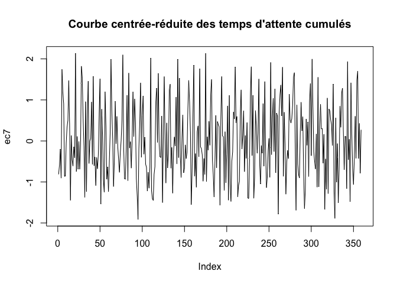

```r
ec7 <- (x.sum[7:365] - rmean) /sd7

# ec7 <- x.sum
# max(as.Date(h10$ENTREE))
# min(as.Date(h10$ENTREE))
# length(x.sum)
# length(sd7)
# length(rmean)

plot(ec7, type="l", main = "Courbe centrée-réduite des temps d'attente cumulés")
```

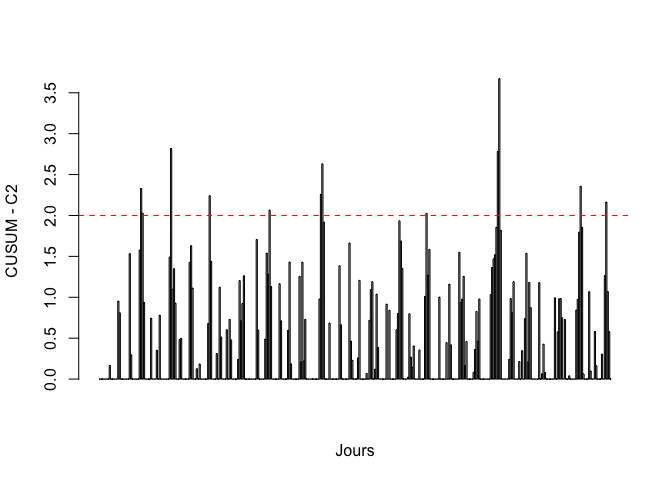

```r
# source: passages.R
c2 <- cusum.c2(ec7)

barplot(c2, ylab = "CUSUM - C2", xlab = "Jours", main = "")
abline(h = 2, lty = 2, col = "red")
```

Référence sur le CUSUM:

- [Détection malformations congénitales et application avec R](http://math.univ-bpclermont.fr/biblio/rapport/sante/2010/M2_Beye_10.pdf)
- [Surveillance sanitaire à partir de donnees des services d’urgence : modélisation de séries temporelles et analyse automatique](http://dumas.ccsd.cnrs.fr/dumas-00516268/document) + programmes R.
- [aussi](http://jess2014.emse.fr/pdf/W4-1-Sarazin-Sentinelles.pdf)

# Variation durées de passage par mois

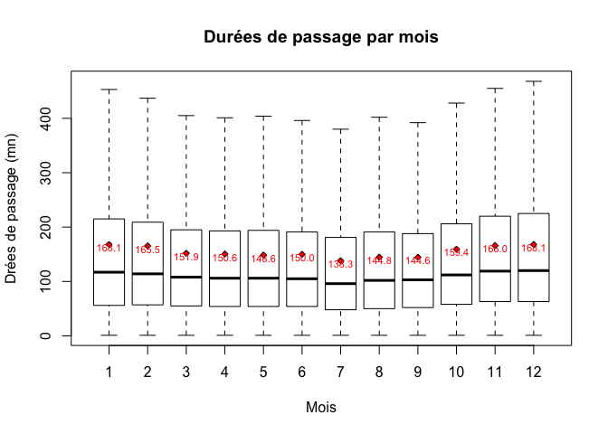

```
## Call:
##    aov(formula = DPAS ~ mois, data = dpas.heure)
##
## Terms:
##                        mois   Residuals
## Sum of Squares       358652 10954538176
## Deg. of Freedom           1      372065
##
## Residual standard error: 171.5883
## Estimated effects may be unbalanced
```

```
##                 Df    Sum Sq Mean Sq F value   Pr(>F)
## mois             1 3.587e+05  358652   12.18 0.000483 ***
## Residuals   372065 1.095e+10   29443
## ---
## Signif. codes:  0 '***' 0.001 '**' 0.01 '*' 0.05 '.' 0.1 ' ' 1
```

```
##
## Call:
## lm(formula = DPAS ~ mois, data = dpas.heure)
##
## Coefficients:
## (Intercept)         mois
##    152.9952       0.2834
```

```
##
## Call:
## lm(formula = DPAS ~ mois, data = dpas.heure)
##
## Residuals:
##     Min      1Q  Median      3Q     Max
## -155.40  -99.70  -46.11   46.15 2726.44
##
## Coefficients:
##              Estimate Std. Error t value Pr(>|t|)
## (Intercept) 152.99520    0.61879  247.25  < 2e-16 ***
## mois          0.28337    0.08119    3.49 0.000483 ***
## ---
## Signif. codes:  0 '***' 0.001 '**' 0.01 '*' 0.05 '.' 0.1 ' ' 1
##
## Residual standard error: 171.6 on 372065 degrees of freedom
## Multiple R-squared:  3.274e-05,  Adjusted R-squared:  3.005e-05
## F-statistic: 12.18 on 1 and 372065 DF,  p-value: 0.0004827
```

```
## Analysis of Variance Table
##
## Response: DPAS
##               Df     Sum Sq Mean Sq F value    Pr(>F)
## mois           1 3.5865e+05  358652  12.181 0.0004827 ***
## Residuals 372065 1.0955e+10   29443
## ---
## Signif. codes:  0 '***' 0.001 '**' 0.01 '*' 0.05 '.' 0.1 ' ' 1
```